# Final Individual Project — The Shifting Landscape of Global Clinical Trials

## What 13,748 Pharmaceutical Trials (1984–2020) Reveal About Drug Development

**Author:** Shirisha Shashidhar Reddy **Course:** Data Visualization — Summer 2026

**Dataset:** [ClinicalTrials.gov](https://clinicaltrials.gov) trial records for 10 major pharmaceutical sponsors, sourced via Kaggle ([*A Quick Overview of Clinical Trials*](https://www.kaggle.com/datasets/thedevastator/a-quick-overview-of-clinical-trials)) — real regulatory registry data, not a synthetic or teaching dataset.

**Why this dataset:** I spent three years in enterprise business analysis at IQVIA, working across major pharmaceutical accounts (AbbVie, Organon, Merck, Pfizer) on data governance, transparency reporting, and CRM systems that support clinical operations. This project lets me apply what I learned this semester to an industry I already understand from the inside — and ask questions I genuinely wanted answered.

**Links:**

- GitHub repository: github.com/shirisha-shashidhar/clinical-trials-final-project
- Live dashboard: siris-clinical-trials.streamlit.app

```python
import pandas as pd
import numpy as np
import plotly.express as px
import plotly.graph_objects as go

df = pd.read_csv('data/clinical_trials.csv')
print(f"Loaded: {len(df):,} trials, {df.shape[1]} columns")
df.head()
```

```
Loaded: 13,748 trials, 11 columns
```

|  | index | NCT | Sponsor | Title | Summary | Start_Year | Start_Month | Phase | Enrollment | Status | Condition |
| --- | --- | --- | --- | --- | --- | --- | --- | --- | --- | --- | --- |
| 0 | 0 | NCT00003305 | Sanofi | A Phase II Trial of Aminopterin in Adults and ... | RATIONALE: Drugs used in chemotherapy use diff... | 1997 | 7 | Phase 2 | 75 | Completed | Leukemia |
| 1 | 1 | NCT00003821 | Sanofi | Phase II Trial of Aminopterin in Patients With... | RATIONALE: Drugs used in chemotherapy use diff... | 1998 | 1 | Phase 2 | 0 | Withdrawn | Endometrial Neoplasms |
| 2 | 2 | NCT00004025 | Sanofi | Phase I/II Trial of the Safety, Immunogenicity... | RATIONALE: Vaccines made from a person's white... | 1999 | 3 | Phase 1/Phase 2 | 36 | Unknown status | Melanoma |
| 3 | 3 | NCT00005645 | Sanofi | Phase II Trial of ILX295501 Administered Orall... | RATIONALE: Drugs used in chemotherapy use diff... | 1999 | 5 | Phase 2 | 0 | Withdrawn | Ovarian Neoplasms |
| 4 | 4 | NCT00008281 | Sanofi | A Multicenter, Open-Label, Randomized, Three-A... | RATIONALE: Drugs used in chemotherapy use diff... | 2000 | 10 | Phase 3 | 0 | Unknown status | Colorectal Neoplasms |

## Preliminary Exploratory Data Analysis (EDA)

```python
print(df.info())
print()
print(df.describe(include='all').T)
```

```
<class 'pandas.core.frame.DataFrame'>
RangeIndex: 13748 entries, 0 to 13747
Data columns (total 11 columns):
 #   Column       Non-Null Count  Dtype
---  ------       --------------  -----
 0   index        13748 non-null  int64
 1   NCT          13748 non-null  object
 2   Sponsor      13748 non-null  object
 3   Title        13604 non-null  object
 4   Summary      13748 non-null  object
 5   Start_Year   13748 non-null  int64
 6   Start_Month  13748 non-null  int64
 7   Phase        13485 non-null  object
 8   Enrollment   13748 non-null  int64
 9   Status       13748 non-null  object
 10  Condition    13748 non-null  object
dtypes: int64(4), object(7)
memory usage: 1.2+ MB
None

               count unique                        top   freq         mean  \
index        13748.0    NaN                        NaN    NaN       6873.5
NCT            13748  13748                NCT00003305      1          NaN
Sponsor        13748     10                        GSK   2473          NaN
Title          13604  13434    Human Photoallergy Test      7          NaN
Summary        13748  13565                     #NAME?     11          NaN
Start_Year   13748.0    NaN                        NaN    NaN  2009.155586
Start_Month  13748.0    NaN                        NaN    NaN     6.691155
Phase          13485      7                    Phase 3   4887          NaN
Enrollment   13748.0    NaN                        NaN    NaN   440.783678
Status         13748      9                  Completed  10568          NaN
Condition      13748    867  Diabetes Mellitus, Type 2    536          NaN

                     std     min      25%     50%       75%      max
index        3968.850085     0.0  3436.75  6873.5  10310.25  13747.0
NCT                  NaN     NaN      NaN     NaN       NaN      NaN
Sponsor              NaN     NaN      NaN     NaN       NaN      NaN
Title                NaN     NaN      NaN     NaN       NaN      NaN
Summary              NaN     NaN      NaN     NaN       NaN      NaN
Start_Year      4.797615  1984.0   2006.0  2009.0    2013.0   2020.0
Start_Month     3.486359     1.0      4.0     7.0      10.0     12.0
Phase                NaN     NaN      NaN     NaN       NaN      NaN
Enrollment   1944.530768     0.0     40.0   124.0     365.0  84496.0
Status               NaN     NaN      NaN     NaN       NaN      NaN
Condition            NaN     NaN      NaN     NaN       NaN      NaN
```

```python
print("Missing values per column:")
print(df.isnull().sum())
print()
print(f"Year range: {df['Start_Year'].min()}–{df['Start_Year'].max()}")
print(f"Sponsors ({df['Sponsor'].nunique()}): {sorted(df['Sponsor'].unique())}")
print()
print("Phase counts:")
print(df['Phase'].value_counts(dropna=False))
print()
print(f"Unique conditions studied: {df['Condition'].nunique()}")
print()
print("Trial status counts:")
print(df['Status'].value_counts())
```

```
Missing values per column:
index            0
NCT              0
Sponsor          0
Title          144
Summary          0
Start_Year       0
Start_Month      0
Phase          263
Enrollment       0
Status           0
Condition        0
dtype: int64

Year range: 1984–2020
Sponsors (10): ['AbbVie', 'Bayer', 'GSK', 'Gilead', 'JNJ', 'Merck', 'Novartis', 'Pfizer', 'Roche', 'Sanofi']

Phase counts:
Phase
Phase 3            4887
Phase 2            3596
Phase 1            2516
Phase 4            2015
Phase 1/Phase 2     322
NaN                 263
Phase 2/Phase 3     139
Early Phase 1        10
Name: count, dtype: int64

Unique conditions studied: 867

Trial status counts:
Status
Completed                  10568
Terminated                  1285
Recruiting                   800
Active, not recruiting       646
Withdrawn                    291
Not yet recruiting           108
Unknown status                19
Suspended                     16
Enrolling by invitation       15
Name: count, dtype: int64
```

## Q1 — How does enrollment size differ across trial phases?

Trial phases progress from small safety studies (Phase 1) to large confirmatory trials (Phase 3) to post-market studies (Phase 4). Does enrollment scale the way the textbook says it should?

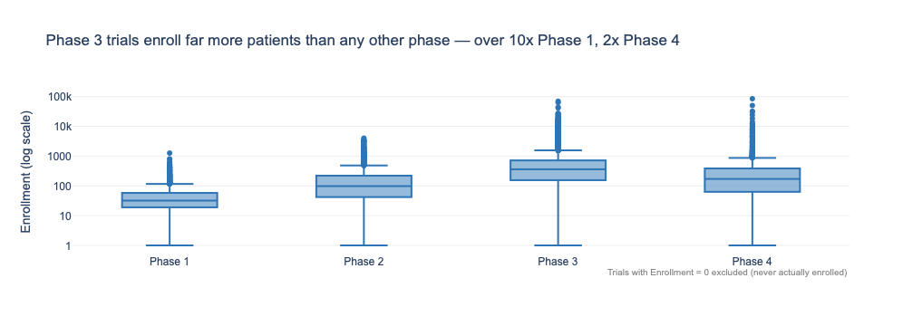

```python
main_phases = ['Phase 1', 'Phase 2', 'Phase 3', 'Phase 4']
q1 = df[(df['Enrollment'] > 0) & (df['Phase'].isin(main_phases))].copy()

fig1 = px.box(
    q1, x='Phase', y='Enrollment', category_orders={'Phase': main_phases},
    color_discrete_sequence=['#2E75B6'],  # single hue — one metric across ordered categories
    log_y=True,  # enrollment is heavily right-skewed (max 84K, median 124) — log scale needed
    labels={'Enrollment': 'Enrollment (log scale)', 'Phase': ''},
    title='Phase 3 trials enroll far more patients than any other phase — over 10x Phase 1, 2x Phase 4'
)
fig1.update_layout(plot_bgcolor='white', paper_bgcolor='white', font=dict(family='Arial', size=12),
                   xaxis=dict(showgrid=False), yaxis=dict(gridcolor='#EEEEEE'))
fig1.add_annotation(text='Trials with Enrollment = 0 excluded (never actually enrolled)',
                    xref='paper', yref='paper', x=1, y=-0.15, showarrow=False,
                    font=dict(size=10, color='#888888'))
fig1.show()
```

## Q2 — Which sponsor's trials are terminated or withdrawn most often, and is that linked to how many trials they run?

A high termination/withdrawal rate could signal riskier R&D bets — or just be noise from a sponsor running very few trials. This checks both at once.

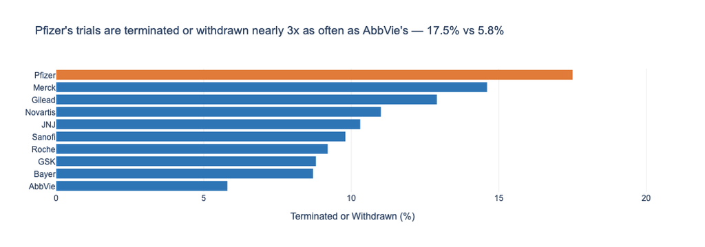

```
    Sponsor  total  bad  rate
7    Pfizer   1970  344  17.5
5     Merck   1770  258  14.6
3    Gilead    417   54  12.9
6  Novartis   2320  256  11.0
4       JNJ   1143  118  10.3
9    Sanofi   1524  149   9.8
8     Roche   1095  101   9.2
2       GSK   2473  218   8.8
1     Bayer    619   54   8.7
0    AbbVie    417   24   5.8
```

```python
df['bad_outcome'] = df['Status'].isin(['Terminated', 'Withdrawn'])
sponsor_stats = df.groupby('Sponsor').agg(total=('NCT', 'count'), bad=('bad_outcome', 'sum')).reset_index()
sponsor_stats['rate'] = (sponsor_stats['bad'] / sponsor_stats['total'] * 100).round(1)
sponsor_stats = sponsor_stats.sort_values('rate', ascending=True)

# BBD HIGHLIGHT colour: orange marks the sponsor with the highest rate, blue-grey for the rest
sponsor_stats['highlight'] = sponsor_stats['Sponsor'].apply(
    lambda s: 'Highest' if s == sponsor_stats.loc[sponsor_stats['rate'].idxmax(), 'Sponsor'] else 'Other')

fig2 = px.bar(
    sponsor_stats, x='rate', y='Sponsor', orientation='h', color='highlight',
    color_discrete_map={'Highest': '#E07B39', 'Other': '#2E75B6'},  # CVD-safe blue/orange, no red-green
    labels={'rate': 'Terminated or Withdrawn (%)', 'Sponsor': ''},
    title="Pfizer's trials are terminated or withdrawn nearly 3x as often as AbbVie's — 17.5% vs 5.8%"
)
fig2.update_layout(plot_bgcolor='white', paper_bgcolor='white', font=dict(family='Arial', size=12),
                   showlegend=False, xaxis=dict(gridcolor='#EEEEEE', range=[0, sponsor_stats['rate'].max()*1.15]))
fig2.update_traces(marker_line_width=0)
fig2.show()

print(sponsor_stats[['Sponsor', 'total', 'bad', 'rate']].sort_values('rate', ascending=False))
```

## Q3 — Has the mix of trial phases shifted over time — is the industry moving toward earlier or later-stage research?

Comparing the 1990s, 2000s, and 2010s only (the 1980s and 2020s have too few trials — 1 and 2 respectively — to be meaningful).

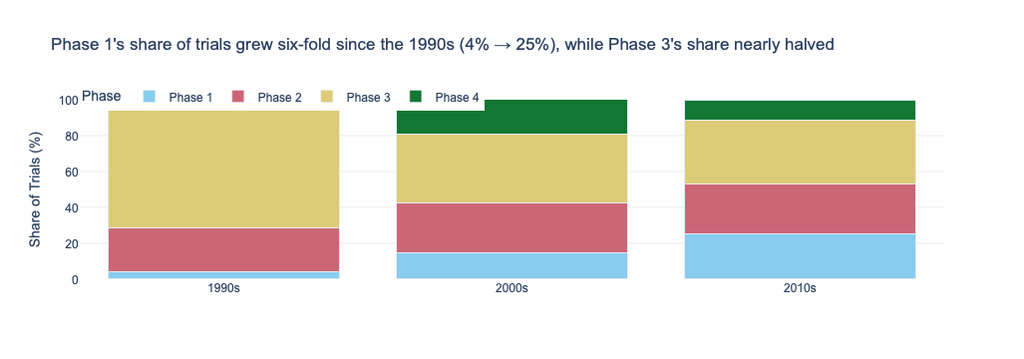

```python
df['decade'] = (df['Start_Year'] // 10 * 10).astype(str) + 's'
q3 = df[df['Phase'].isin(main_phases) & df['decade'].isin(['1990s', '2000s', '2010s'])]
q3_ct = (pd.crosstab(q3['decade'], q3['Phase'], normalize='index') * 100).round(1)[main_phases]
q3_long = q3_ct.reset_index().melt(id_vars='decade', var_name='Phase', value_name='Share')

# BBD CATEGORICAL colour: Plotly's built-in CVD-safe qualitative palette (Okabe-Ito based)
fig3 = px.bar(
    q3_long, x='decade', y='Share', color='Phase', barmode='stack',
    category_orders={'decade': ['1990s', '2000s', '2010s'], 'Phase': main_phases},
    color_discrete_sequence=px.colors.qualitative.Safe,
    labels={'Share': 'Share of Trials (%)', 'decade': ''},
    title="Phase 1's share of trials grew six-fold since the 1990s (4% → 25%), while Phase 3's share nearly halved"
)
fig3.update_layout(plot_bgcolor='white', paper_bgcolor='white', font=dict(family='Arial', size=12),
                   yaxis=dict(gridcolor='#EEEEEE', range=[0, 100]), xaxis=dict(showgrid=False),
                   legend=dict(orientation='h', y=1.1))
fig3.show()
```

## Q4 — Which disease areas saw the sharpest rise or fall in trial activity between the 2000s and 2010s?

Looking at the 12 most-studied conditions overall, comparing trial counts in each decade.

```python
top_conditions = df['Condition'].value_counts().head(12).index.tolist()
q4 = df[df['Condition'].isin(top_conditions) & df['decade'].isin(['2000s', '2010s'])]
q4_ct = pd.crosstab(q4['Condition'], q4['decade'])

fig4 = go.Figure()
for cond in q4_ct.index:
    v2000s, v2010s = q4_ct.loc[cond, '2000s'], q4_ct.loc[cond, '2010s']
    increased = v2010s > v2000s
    # CVD-safe: blue = grew, orange = shrank (no red/green)
    color = '#2E75B6' if increased else '#E07B39'
    fig4.add_trace(go.Scatter(
        x=['2000s', '2010s'], y=[v2000s, v2010s], mode='lines+markers+text',
        line=dict(color=color, width=2.5), marker=dict(color=color, size=7),
        text=[f'{cond}: {v2000s}', f'{v2010s}'], textposition=['middle left', 'middle right'],
        textfont=dict(size=10), showlegend=False
    ))

fig4.update_layout(
    title='Hepatitis and COPD trial activity grew fastest since the 2000s — schizophrenia and hypertension fell sharpest',
    plot_bgcolor='white', paper_bgcolor='white', font=dict(family='Arial', size=12),
    yaxis=dict(showticklabels=False, title='', showgrid=False),
    xaxis=dict(showgrid=False), margin=dict(l=180, r=140)
)
fig4.show()
```

[output not shown]

## Q5 — Are early-phase trials more likely to be terminated or withdrawn than late-phase trials?

The intuition is that early, exploratory trials should be riskier. Is that actually true here?

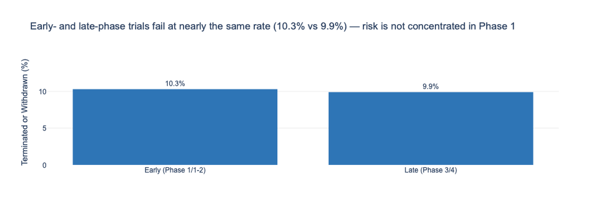

```python
stage_map = {'Phase 1': 'Early (Phase 1/1-2)', 'Phase 1/Phase 2': 'Early (Phase 1/1-2)',
             'Phase 3': 'Late (Phase 3/4)', 'Phase 4': 'Late (Phase 3/4)'}
q5 = df[df['Phase'].isin(stage_map.keys())].copy()
q5['stage'] = q5['Phase'].map(stage_map)
q5_rate = q5.groupby('stage')['bad_outcome'].mean().mul(100).round(1).reset_index()
q5_rate.columns = ['stage', 'rate']

fig5 = px.bar(
    q5_rate, x='stage', y='rate',
    color_discrete_sequence=['#2E75B6'],  # single hue — comparing one metric across 2 groups
    labels={'rate': 'Terminated or Withdrawn (%)', 'stage': ''},
    title='Early- and late-phase trials fail at nearly the same rate (10.3% vs 9.9%) — risk is not concentrated in Phase 1'
)
fig5.update_layout(plot_bgcolor='white', paper_bgcolor='white', font=dict(family='Arial', size=12),
                   yaxis=dict(gridcolor='#EEEEEE', range=[0, max(q5_rate['rate'])*1.4]), xaxis=dict(showgrid=False))
fig5.update_traces(marker_line_width=0, texttemplate='%{y}%', textposition='outside')
fig5.show()
```